# Quarto를 활용한 대시보드 제작

Author

이상일, 전혜민, 김세창, 김우형

Published

July 27, 2025

# 1 실습 목표

Quarto를 이용하여 데이터 대시보드(dashboard) 만들기

# 2 Quarto 문서 생성

R studio를 열고 **File** > **New File** > **Quarto Document**를 실행한다. Title과 Author란에 적절한 텍스트를 기입하고 아래에 위치한 Create 버튼을 클릭한다.

[figure not shown]

새로운 Quarto 문서 생성

그렇다면 아래의 화면이 보일 것이다.

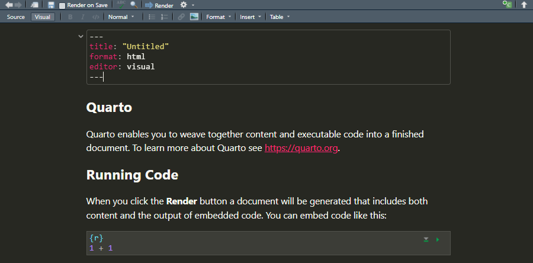

Figure 1: 새로 생성된 Quarto 문서

## 2.1 Quarto 문서의 구조

[figure not shown]

Figure 2: Quarto의 기본 구조

Quarto 문서는 두 개의 서로 다른 에디터를 사용하여 편집할 수 있다. Figure 2 에서 왼쪽은 비주얼 에디터(visual editor), 오른쪽은 소스 에디터(source editor)를 사용한 것이다. 소스 에디터는 Notion과 유사한 마크다운 형식을 사용하며, 비주얼 에디터는 마치 워드프로세서를 다루듯 Quarto 문서를 작성할 수 있다.

Quarto 문서는 크게 세 부분으로 나뉘어진다.

- YAML 헤더(header)
- 코드 청크(code chunk)
- 마크다운 텍스트

## 2.2 YAML 헤더

이 밖에도 다양한 key가 존재하는데, [링크](https://quarto.org/docs/reference/formats/html.html)에서 자세한 정보를 확인할 수 있다. 보통 아래의 것들이 중요하다.

| key | 설명 |
| --- | --- |
| title | 다큐먼트의 제목 |
| date | 다큐먼트 작성 날짜 |
| author | 다큐먼트 저자 이름 |
| format | 다양한 포맷 관련 사항의 지정 |
| toc | 목차 삽입 |
| number-section | 섹션 제목에 자동 번호 부여 여부 |
| execute: echo | 소스 코드의 포함 여부를 글로벌하게 설정, 보통 true |
| execute: warning | 경고 메시지를 산출물에 나타나게 할지를 글로벌하게 설정, 보통 false |
| editor | 비주얼 에디터와 소스 에디터 중 선택, 보통 visual |
| freeze | 렌더링 옵션을 지정, 보통 auto |

`---` 으로 둘러싸인 YAML에 아래와 같은 몇 가지 `key: value` 를 더해보자.

```r
---
number-sections: true
format:
  html:
    toc: true
execute:
  warning: false
  error: false
  freeze: auto
---
```

## 2.3 코드 청크

프로그래밍 언어의 코드가 들어가는 부분이다. R을 사용하는 경우 `{r}`로 시작한다. 지금까지 배운 코드들이 여기에 들어갈 수 있다. 보통 하나의 Quarto 문서 내에 다수의 코드 청크가 포함된다. 각 코드 청크 내에서 코드를 실행할 수 있는데, 한 단위씩 실행할 때는 **ctrl(또는 Cmd) + enter**, 한 코드 청크 내 모든 코드를 실행하고자 할 때는 **ctrl(또는 Cmd) + shift + enter** 단축키를 사용한다.

각 코드 청크 앞 부분에 해당 코드 청크와 관련된 다양한 옵션을 `#|` 형태로 삽입할 수 있는데, YAML 헤더에서처럼 `key: value`의 형태를 띤다. 아래의 옵션들은 코드 청크의 내용이나 실행 결과, 오류 메시지 등이 최종 산출물에 어떻게 표현되는지 결정하는 것들이다. 이 밖에도 다양한 옵션들이 존재하는데, 구글링 혹은 [Quarto 공식 가이드](https://quarto.org/docs/guide/)를 참고하자.

| Option | Run code | Show code | Output | Plots | Messages | Warnings |
| --- | --- | --- | --- | --- | --- | --- |
| `eval: false` | X |  | X | X | X | X |
| `include: false` |  | X | X | X | X | X |
| `echo: false` |  | X |  |  |  |  |
| `results: hide` |  |  | X |  |  |  |
| `fig-show: hide` |  |  |  | X |  |  |
| `message: false` |  |  |  |  | X |  |
| `warning: false` |  |  |  |  |  | X |

## 2.4 마크다운 텍스트

Quarto는 기본적으로 마크다운 텍스트 작성을 기반으로 하고 있다. 마크다운 텍스트 작성에 앞서 언급한 비주얼 에디터는 큰 역할을 하는데, 이는 마크다운 언어의 사용자 편의성을 한번 더 강화한 것으로 볼 수 있다.

기본적인 Quarto 작성법은 다음과 같다.

- 텍스트: 그냥 작성
- 코드 청크(Code Chunk): **Insert > Executable Cell > R**(Ctrl+Alt+I)
- 표(Table): **Insert > Table**
- 그림(Figure): **Insert > Figure**
- 링크(Link): (원하는 텍스트 선택 후) **Insert > Link**
- 머릿말(Header): **Normal > Header 1~6** 중 선택

모든 내용이 작성되었다면 상단의 Render 버튼을 누르거나 단축키 Ctrl+Shift+K로 결과물을 렌더링할 수 있다.

## 2.5 Quarto 문서 작성 팁

추가로 몇 가지의 팁을 소개한다.

첫째, R의 패키지나 함수를 다르게 표시할 수 있다. 지금까지의 실습록에서 tidyverse 함수를 `tidyverse` 와 같이 표시하던 것이 기억날 것이다. 이는 해당 텍스트를 선택한 후, Format에서 Code를 누르면 생성된다. 혹은 Ctrl+D로 실행할 수 있다.

둘째, `Call-out` 이다. 문서 중간에 팁이나 주의를 알려주고 있다.

**Tip**

Callout은 문서 중간에 팁이나 주의를 알려주는데 사용할 수 있다.

Callout에는 공지(note), 팁(tip), 중요사항(important), 주의(caution), 경고(warning) 등이 있다. 이는 비주얼 에디터 메뉴 Insert-Callout에서 선택할 수 있고, `:::` 으로 둘러싸인 부분에 글이나 코드 청크를 작성하면 된다. 다양한 Callout의 옵션은 [공식 가이드](https://quarto.org/docs/authoring/callouts.html)에서 찾아볼 수 있다.

## 2.6 Quarto 문서 작성

위에서 배운 내용을 기반으로 간단한 Quarto 문서를 작성해본다.

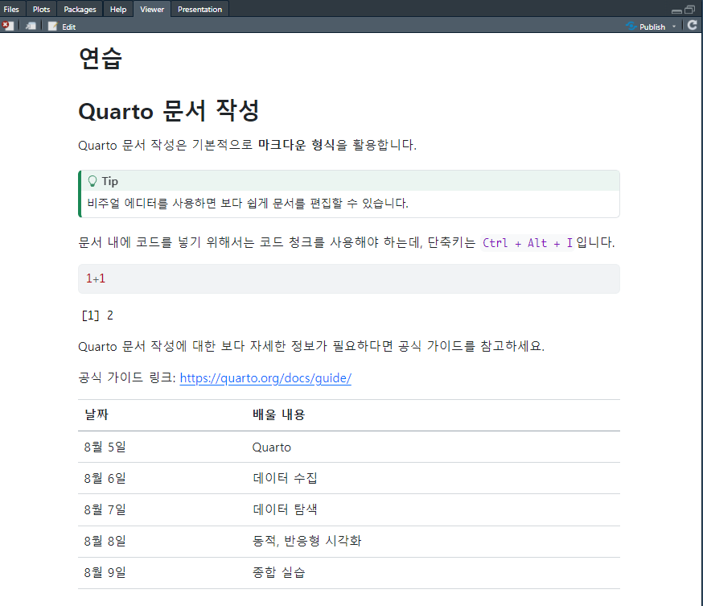

# 3 대시보드의 기본 구조

대시보드는 기본적으로 다섯 가지의 구성요소로 이루어진다. 각각은 메인 바디, 헤더, 내비게이터, 사이드바, 푸터이다.

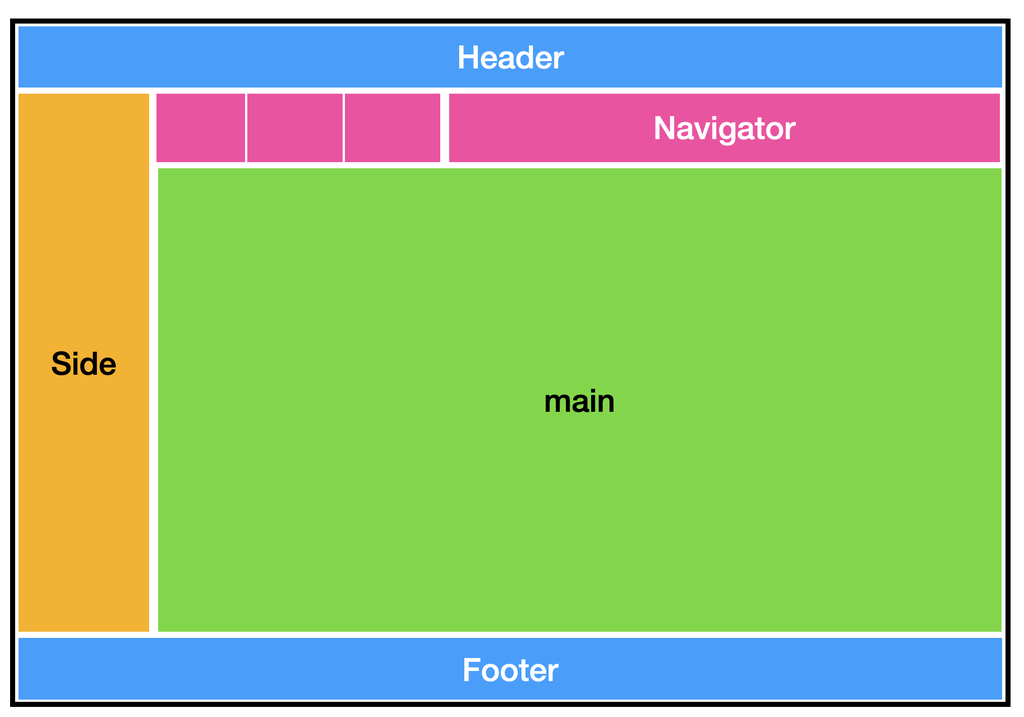

https://blog.zarathu.com/posts/2023-12-11-quarto-dashboard/#tabset

첫째, **메인 바디(main body)**는 대시보드의 핵심 요소이다. 메인 바디는 카드(card)라고 불리는 기본 단위들로 구성된다. 개별 카드는 다양한 내용 요소(텍스트, 그래프, 표, 지도, 밸류박스 등)를 가질 수 있다. 즉, 어떤 카드 속에는 그래프가 들어가며, 어떤 카드 속에는 지도가 들어간다. 이러한 카드들은 특정한 레이아웃 요소(페이지, 행, 열, 탭셋 등)를 통해 메인 바디에 배열된다. 페이지(page)는 대시보드 레이아웃 요소 중 최상위 레벨인데, 개별 페이지는 다수의 행(row) 혹은 열(column)로 구성된다. 행 혹은 열을 또다른 행 혹은 열이 아닌 탭 클릭 방식으로 분할하고 싶을 때 탭셋(tabset)이 사용된다.

둘째, **헤더(header)**는 대시보드의 가장 중요한 메타 정보(로고, 제목, 저자 등)를 포함한다.

셋째, **내비게이터(navigator)**는 최상위 레이아웃인 페이지간 이동을 통제한다.

넷째, **사이드바(sidebar)**는 주로 사용자의 인풋(input)을 받을 때 사용되는 것으로, 동적인 대시보드에서 주로 사용된다. Quarto는 사이드바 외에 툴바(toolbar)와 카드인풋(card input)과 같은 옵션을 제공한다.

다섯째, **푸터(footer)**는 헤더와 유사한 기능을 하는데, 주로 부차적인 매타 정도를 포함한다.

다섯개의 구성 요소 중 가장 중요한 것은 메인 바디, 해더, 내비게이터이다. Quarto는 헤더와 내비게이터를 통합한 내비게이션바(navigation bar)를 제공한다. 사이드바는 `Shiny` 패키지를 활용한 동적인 대시보드에서는 매우 중요하지만, 이번 실습에서는 사용하지 않는다. 푸터는 가장 지엽적인 요소이다.

다음의 대시보드를 살펴보자.

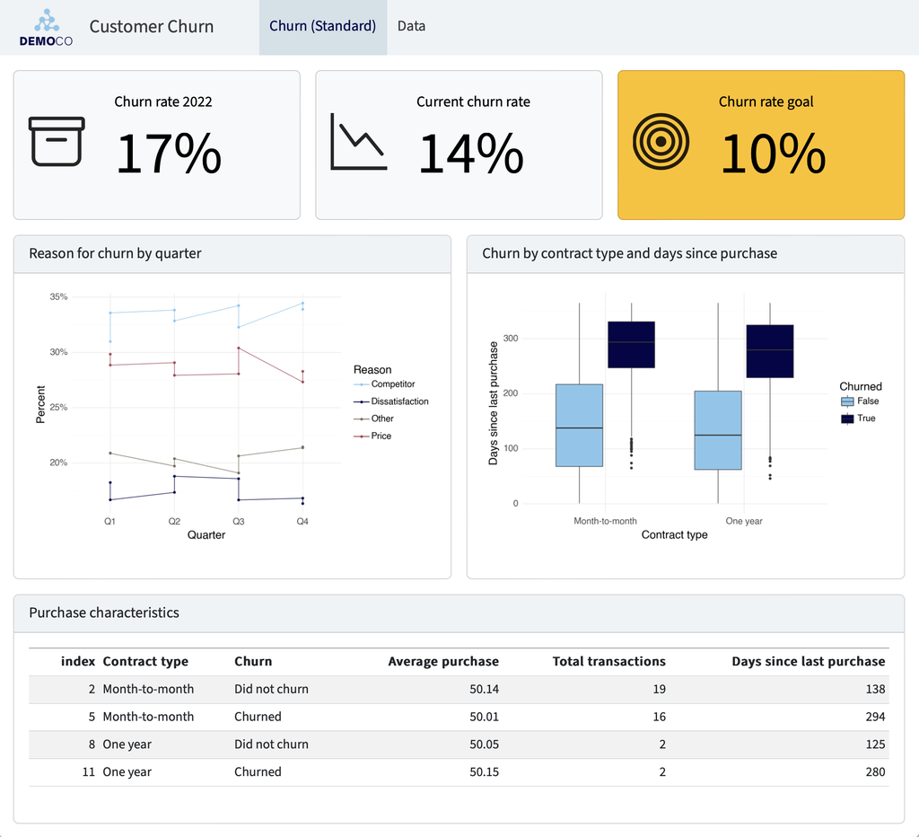

https://quarto.org/docs/dashboards/

이 대시보드는 크게 내비게이션바와 메인 바디로 구성되어 있다. 네비게이션바에는 다음의 내용이 포함되어 있다.

- 이 대시보드의 제목(title)은 ’고객이탈(Customer Chrun)’이고 회사 이름은 DEMOCO(로고)이다.
- 이 대시보드는 모두 두 개의 페이지(page)로 구성되어 있다. 페이지의 이름은 각각 ’Churn (Standard)’과 ’Data’이다.

메인 바디는 다음과 같은 레이아웃 요소들로 구성되어 있다.

- 첫 번째 페이지(Churn (Standard))는 세 개의 행(row)으로 구성되어 있다.
- 첫 번째 페이지의 첫 번째 행은 세 개의 카드(card)로 구성되어 있는데, 내용 요소는 모두 밸류박스(value box)이다.
- 첫 번째 페이지의 두 번째 행은 두 개의 열(즉, 카드)로 구성되어 있는데, 내용 요소는 모두 그래프(graph)이다.
- 첫 번째 페이지의 세 번째 행은 단일한 열(즉, 카드)로 구성되어 있는데, 내용 요소는 테이블(table)이다.
- 두 번째 페이지에도 다양한 사항이 포함되어 있을 것이다.

이 밖에도 다양한 대시보드의 예시를 [Quarto 갤러리](https://quarto.org/docs/gallery/)에서 찾아볼 수 있다.

# 4 레이아웃 설정법

기초적인 레이아웃 설정에 대한 내용을 다룬다. 보다 자세한 내용은 [공식 문서](https://quarto.org/docs/dashboards/layout.html#layout)에서 확인할 수 있다.

## 4.1 페이지의 설정

페이지(page)는 최상위 레이아웃 요소이다. 기본 원칙은 다음과 같다.

- 헤더 1(header 1) 레벨이 페이지의 구분을 결정한다.
- Quarto에서는 페이지가 내비게이션바에 나타난다.

```r
# Page A

# Page B
```

## 4.2 내비게이션 바의 설정

내비게이션바는 헤더와 내비게이터로 구성된다. 내비게이터는 페이지가 설정된 경우에만 나타나게 된다. 헤더는 다른 Quarto 문서와 마찬가지로 YAML 헤더를 통해 통제된다.

- 제목(title): 대시보드 전체의 이름을 결정한다.
- 저자(author): 만든 사람이나 관리 회사의 이름이지만, 부제로 활용되기도 한다.
- 포맷(format): 기본 설정인 대시보드(dashboard) 하에 다양한 하위 설정이 가능하다.
  - logo: 로고 그림 파일을 지정하면 내비게이션바의 왼쪽 끝에 나타난다.
  - nav-buttons: github이나 이메일 연결을 설정할 수 있다.
  - scrolling: true 설정: 디폴트는 false인데, 레이아웃 요소들의 높이들의 합이 100%가 되도록 일괄적으로 조절된다. true로 지정하면, 개별 내용 요소의 원 크기를 그대로 살리면서 스크롤되게 디자인이 바뀐다. 둘 다를 실험해 보고 자신의 목적에 맞는 것을 고른다.
- 테마(theme): 대시보드의 외관을 한꺼번에 바꿀 수 있다. 모두 25개의 [부트스와치(bootswatch)](https://quarto.org/docs/dashboards/theming.html) 테마가 존재한다. 여러가지를 실험해 보고 자신의 취향에 맞는 것을 선정한다.

자세한 사항은 아래의 예시 대시보드 만들기에서 확인한다.

## 4.3 사이드바의 설정

사이드바(sidebar)는 `{.sidebar}` 태그를 통해 만들 수 있는데, 헤더 1(header 1) 레벨이므로 특정한 페이지에 종속되지 않는다. 사이드바는 주로 사용자의 투입을 받을 때 사용되기 때문에 동적인 대시보드에 주로 사용된다. 정적인 대시보드의 경우에는 텍스트를 통한 특정 정보의 제공에 사용될 수 있다.

```r
# {.sidebar}
Sidebar content
```

## 4.4 행과 열의 설정

행(row)과 열(column)은 가장 기본이 되는 레이아웃 요소이다. 기본 원칙은 다음과 같다.

- 헤더 2(header 2) 레벨이 행의 구분을 일차적으로 결정한다.
- 헤더 3(header 3) 레벨이 하위 열의 구분을 이차적으로 결정한다.
- Row와 Column 옆에 `{height}`, `{width}` 태그를 통해 가로 세로의 상대적인 크기를 정한다.
- 기본적으로는 행을 먼저 구분하도록 설정되어 있다. 만약 헤더 2를 통해 열을, 헤더 3을 통해 행을 구분하고 싶다면, yaml header의 `dashboard:` 아래 `orientation: columns`를 추가해야 한다.

```r
## Row {height=70%}

Card 1

## Row {height=30%}

### Column {width=40%}

Card 2-1

### Column {width=60%}

Card 2-2

# Page B

Card 3
```

## 4.5 탭셋의 설정

Row나 Column에 {.tabset}을 표기하면, 하위의 행과 열이 탭으로 구분된다. 이렇게 하면 카드의 크기가 지나치게 줄어드는 단점을 해소할 수 있다.

## 4.6 기본 구조 살펴보기

위를 바탕으로 대시보드의 골격을 작성해본다.

```r
---
title: "dashboard"
format: dashboard
theme: default
editor: visual
editor_options:
  chunk_output_type: console
---

# {.sidebar}
Sidebar content

# Page A

## Row {height=70%}

Card 1

## Row {height=30%}

### Column {width=80%} {.tabset}

#### Tab1
Card 2-1

#### Tab2
Card 2-2

### Column {width=20%}

Card 2-3

# Page B

Card 3
```

위와 같이 설정하면 다음과 같은 결과를 얻을 수 있다.

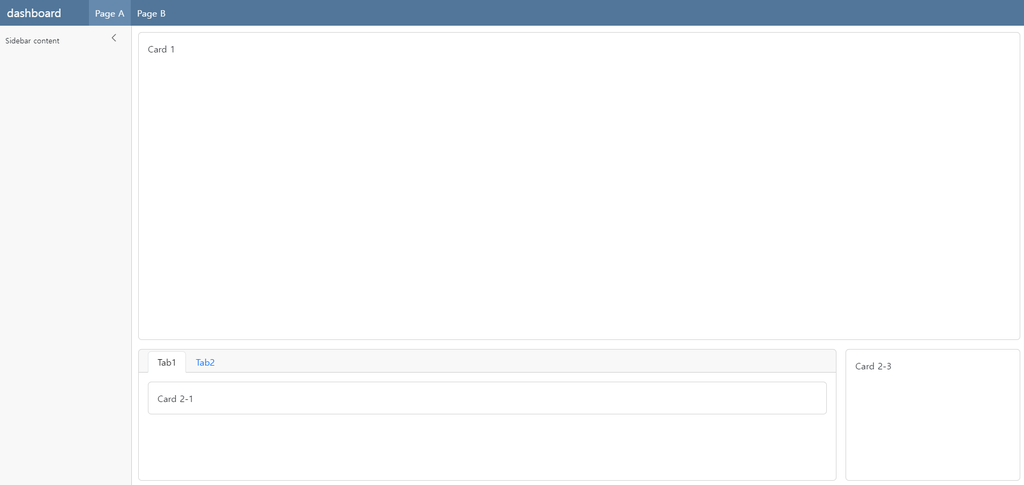

# 5 카드와 내용 요소

카드(card)란 특정한 내용 요소(텍스트, 벨류박스, 테이블, 그래프, 지도 등)를 포함하고 있는, 대시보드의 가장 기본적인 단위이다. 다음의 두 가지 사항이 중요하다.

- 카드의 제목이 중요하다. 완성된 대시보드 상에 등장하기 때문에 사용자가 이해하기 쉬운 제목이 부여되어야 한다.
- 내용 요소에 따라 카드를 작성하는 방법이 조금 다르다.

내용 요소 제작의 세세한 사항은 아래의 “예시 대시보드 만들기”에서 확인한다.

## 5.1 그래프

Quarto는 그래프 하나를 만들어내는 코드 청크를 하나의 카드로 인식한다. 그래프 카드의 제목은 코드 청크 내의 `#| title:` 옵션을 통해 부여된다. `ggplot2`와 같은 정적인 플롯 도구 뿐만 아니라 `plotly`와 같은 반응형 플롯 도구를 사용하여 그래프 카드를 생성한다.

## 5.2 지도

Quarto는 지도 하나를 디스플레이하는 코드 청크를 하나의 카드로 인식한다. 지도 카드의 제목은 코드 청크 내의 `#| title:` 옵션을 통해 부여된다. `ggplot2`와 같은 정적인 지도 제작 도구 뿐만 아니라 [`leaflet`](https://leafletjs.com/)과 같은 반응형 지도 제작 도구를 사용하여 지도 카드를 생성한다.

## 5.3 텍스트

일종의 텍스트 박스도 하나의 카드로 간주된다. 그래프, 테이블, 지도가 하나의 코드 청크가 하나의 카드로 인식되는데 반해 텍스트 카드는 다른 형식을 취한다. `::: {.card}` div를 사용해야 하며 괄호 내부에 `title=` 옵션을 사용해 제목을 지정해야 한다. 가령 `{.card title="Text"}`와 같이 표기해야 한다.

## 5.4 밸류박스

요약적 수치를 큰 박스 속에 나타내는 것을 밸류박스(value box)라고 하는데, 코드 청크로 표현하지만 형식은 조금 다르다. `#| content: valuebox`라는 옵션이 반드시 포함되야 하며, 제목을 지정하기 위해 `#| title:` 옵션도 필요하다. 또한 리스트를 이용해 아이콘(icon), 컬러(color), 수치(value)를 지정해야 한다.

모든 컬러가 다 사용가능한 것은 아니다. 아래의 표를 참조하여 컬러를 설정해야 한다.

| Color Alias | Default Theme Color(s) |
| --- | --- |
| `primary` | Blue |
| `secondary` | Gray |
| `success` | Green |
| `info` | Bright Blue |
| `warning` | Yellow/Orange |
| `danger` | Red |
| `light` | Light Gray |
| `dark` | Black |

# 6 웹사이트 임베딩

대시보드의 컨텐츠를 직접 제작하는 방법도 있지만 이미 잘 만들어진 웹사이트를 대시보드에 불러오는 방법도 있다. 이것을 임베딩(embedding)이라고 하는데, HTML의 `iframe` 태그를 사용한다.

태그의 구조는 다음과 같다.

```r
<iframe
  src= 웹사이트 링크 # iframe으로 불러올 웹페이지의 URL
  loading="lazy" # 화면에 보이기 전까지 iframe 콘텐츠 로딩을 지연(HTML5 표준)
  style="width: ; height: ; border: " # 가로, 세로, 테두리 설정
  allow="web-share; clipboard-write" # iframe 내에서 웹 공유 API 사용, 클립보드 복사 허용>

</iframe>
```

보통 여기에서 `src` 부분만 다르게 작성하고, `width`, `height`, `border`를 알맞게 설정해주면 된다. 다만 웹사이트 자체에서 iframe을 차단하고 있다면 그 웹사이트는 대시보드에 불러와서 사용할 수 없다.

유튜브는 영상 > 공유 > 퍼가기로 iframe 태그를 받을 수 있고, 직접 세부사항을 수정할 수 있다.

```r
<iframe width="800" height="600"
src="https://www.youtube.com/embed/rxOMhQwApMc?si=_K_qCxFqdn4qJTLH"
title="YouTube video player"
frameborder="0"
allow="accelerometer; autoplay; clipboard-write; encrypted-media; gyroscope; picture-in-picture; web-share"
referrerpolicy="strict-origin-when-cross-origin"
allowfullscreen
data-external="1">

</iframe>
```

[video not shown]

[Our World in Data](https://ourworldindata.org/)라는 웹사이트에서는 아름다운 인터랙티브 시각화 자료를 제공하는 것으로 유명하다. 여기에서 원하는 자료를 찾았다면 Share 버튼을 누르고 `</> Embed`라는 옵션을 누르면 iframe 태그가 나와 그것을 그대로 복사-붙여넣기 하면 된다.

```r
<iframe
src="https://archive.ourworldindata.org/20250624-125417/grapher/annual-change-forest-area.html"
loading="lazy"
style="width: 100%; height: 600px; border: 0px none;"
allow="web-share; clipboard-write"
data-external="1">
</iframe>
```

[interactive chart not shown]

# 7 예시 대시보드 만들기

위의 사항을 바탕으로 [예시 대시보드](https://geowhk.quarto.pub/dashboard/)에 접속하여 구성을 살펴본다.

대시보드가 세 개의 페이지(Plot, Map, iframe)로 나뉘어져 있고, 각 페이지마다 행, 열, 탭셋과 같은 레이아웃 요소들이 배치되어 있다.

이 대시보드를 어떻게 제작할 수 있을지 생각해 본다. 대시보드 제작을 위한 Quarto 다큐먼트를 생성한다.

아래는 해당 대시보드를 만들기 위해 사용된 코드이다. 참고하여 자신만의 대시보드를 만들어 본다.

## 7.1 YAML 헤더

다양한 `theme`을 실험해본다. `scrolling:`을 `true`로 두면 대시보드가 상하 스크롤이 가능해져 콘텐츠를 많이 넣을 수 있다는 장점이 있지만, 앞서 레이아웃 설정에서 배운 `{height=}` 옵션 사용이 불가능해진다.

```r
---
title: "dashboard"
format:
  dashboard:
    scrolling: false
theme: flatly
editor: visual
editor_options:
  chunk_output_type: console
---
```

## 7.2 Plot 페이지

```r
# Plot
```

### 7.2.1 첫번째 행: Text 카드

행을 설정하고 행의 상대적인 높이(20%)를 지정한다.

```r
## Row {height="20%"}
```

텍스트 카드를 생성한다. 텍스트 카드를 생성하기 위해 `{.card}` 태그가 사용되어야 하며, 텍스트 카드의 제목을 지정하기 위해 `title=` 옵션이 사용되어야 함에 주의한다.

```r
::: {.card title="Text"}
This is my first dashboard.
:::
```

### 7.2.2 두번째 행의 탭셋: Static Plot

행을 설정하고 행의 상대적인 높이(80%)를 지정한다. 탭셋을 생성하기 위해 `{.tabset}` 태그가 사용되어야 함에 주의한다.

```r
## Row {.tabset height="80%"}
```

그래프 카드를 생성하기 위해 `ggplot2` 패키지를 활용한다. 그래프 카드의 제목을 지정하기 위해 `title=` 옵션이 사용되어야 함에 주의한다. 이때 산출될 플롯의 크기는 `fig-width`와 `fig-height`로 조정할 수 있다.

```r
#| title: Static Plot
#| fig-width: 15
#| fig-height: 6

library(tidyverse)

ggplot(data = iris, aes(x = Petal.Length, y = Petal.Width, color = Species)) +
    geom_point() +
    labs(
        title = "Relationship Between Petal Length and Width", # 그래프 제목
        x = "Petal Length (cm)", # x축 제목
        y = "Petal Width (cm)", # y축 제목
        color = "Species", # 범례 제목
    ) +
    theme_minimal()
```

다음 탭셋에는 인터랙티브 플롯을 생성하기 위해 `ggplotly()` 함수를 활용한다.

```r
#| title: Interactive Plot
#| fig-width: 15
#| fig-height: 6

library(plotly)

p <- ggplot(data = iris, aes(x = Petal.Length, y = Petal.Width, color = Species)) +
        geom_point() +
        labs(
            title = "Relationship Between Petal Length and Width", # 그래프 제목
            x = "Petal Length (cm)", # x축 제목
            y = "Petal Width (cm)", # y축 제목
            color = "Species", # 범례 제목
        )

ggplotly(p)
```

## 7.3 Map 페이지

Map이라는 이름의 페이지를 설정한다.

```r
# Map
```

### 7.3.1 첫번째 열의 그래프 카드: Interactive NDVI Map of Seoul

Map 페이지를 보면 행의 구분 없이 2개의 열로 분할되어 있다. YAML 헤더에서 `orientation: columns` 설정을 하지 않았기 때문에 Row 설정을 먼저한 뒤 바로 Column 설정을 한다.

```r
## Row

### Column {width="50%"}
```

`leaflet` 패키지를 활용하여 그래프 카드를 생성한다.

```r
#| title: "Interactive NDVI Map of Seoul(2025.04.26.)"

library(tidyverse)
library(terra)
library(tidyterra)
library(sf)
library(leaflet)

SIGUN <- st_read("landsat/SIGUN/SIGUN.shp",
                 options = "ENCODING=CP949",
                 quiet = TRUE)
seoul <- SIGUN |>
    filter(
        SG1_NM == "서울특별시"
        )

landsat_seoul <- rast("landsat/landsat_seoul.tif")
landsat_seoul_mask <- landsat_seoul |>
  mask(seoul)

numerator <- landsat_seoul_mask[["B5_NIR"]] - landsat_seoul_mask[["B4_Red"]]
denominator <- landsat_seoul_mask[["B5_NIR"]] + landsat_seoul_mask[["B4_Red"]]
NDVI_2025 <- numerator / denominator

pal_numeric <- colorNumeric(palette = "RdYlGn",
                            values(NDVI_2025),
                            na.color = "transparent"
                            )

leaflet() |>
  addTiles() |>
  addRasterImage(NDVI_2025, colors = pal_numeric, opacity = 0.8) |>
  addLegend(pal = pal_numeric,
            values = values(NDVI_2025),
            title = "NDVI of Seoul"
            )
```

```r
### Column {width="50%"}
```

앞선 페이지와 동일한 방식으로 텍스트를 입력한다.

```r
::: {.card title="What is NDVI?"}
NDVI(Normalized Difference Vegetation Index, 식생지수)는 위성 영상이나 항공 영상을 활용하여 지표면의 식생 상태를 정량적으로 분석하기 위한 대표적인 지표입니다...
```

## 7.4 iframe 페이지

iframe이라는 이름의 페이지를 설정한다.

```r
# iframe
```

텍스트 입력을 위한 행을 설정한다.

```r
## Row {height="12%"}
```

설명 텍스트를 작성한다.

```r
iframe을 통해서 웹사이트를 대시보드에 불러올 수 있는데, 이를 embedding이라고 한다.
```

열을 두개로 분할하고, 왼쪽 열에 YouTube 영상을 iframe으로 가져온다.

```r
### Column {width="50%"}
```

```r
::: {.card title="What is NDVI?"}
<iframe width="1000" height="600" src="https://www.youtube.com/embed/rxOMhQwApMc?si=_K_qCxFqdn4qJTLH" title="YouTube video player" frameborder="0" allow="accelerometer; autoplay; clipboard-write; encrypted-media; gyroscope; picture-in-picture; web-share" referrerpolicy="strict-origin-when-cross-origin" allowfullscreen>

</iframe>
:::
```

오른쪽 열에는 NDVI에 대한 뉴스 기사를 iframe으로 가져와본다.

```r
### Column {width="50%"}
```

```r
::: {.card title="NDVI in News"}
<iframe src="https://www.newstree.kr/newsView/ntr202505140022" loading="lazy" style="width: 100%; height: 600px; border: 0px none;" allow="web-share; clipboard-write">

</iframe>
:::
```

# 8 대시보드 웹 상에 출판하기

블로그와 마찬가지로 다음의 절차에 따라 완성된 대시보드를 웹 상에 출판한다. 여기서는 [Posit](https://posit.co/)에서 제공하는 무료 출판 사이트인 [Quarto Pub](https://quartopub.com/)을 활용한다.

- [Quarto Pub](https://quartopub.com/)에 접속하여 계정을 만든다.
- RStudio에서, 왼쪽 하단부의 Terminal 탭을 누른다.
- 프롬프트에 다음과 같이 입력하고 실행한다

```r
quarto publish quarto-pub (qmd 파일명).qmd
```